# brownian_motion

## Geometric Brownian Motion

Doğukan E. Türköz

```python
# import libraries

import numpy as np
import matplotlib.pyplot as plt
from scipy.stats import norm, lognorm
```

The stochastic differential equation

$$ \dot S(t) = \mu S(t) + \sigma S(t) \xi(t) $$

plays a central role in mathematical finance. This equation describes what is known as [Geometric Brownian Motion](https://en.wikipedia.org/wiki/Geometric_Brownian_motion). $S(t)$ is taken to be positive and represents the value of a stock at time $t$. The deterministic ODE $\dot S(t) = \mu S(t)$, describes exponential growth in the value of a stock. We consider $\mu > 0$ and refer to $\mu$ as the growth rate. The term $\sigma S(t) \xi(t)$ describes fluctuations in the value of a stock. $\xi(t)$ is a Gaussian random variable. The parameter $\sigma > 0$ is known as the volatility. Notice that the fluctuating term contains $S(t)$ itself. This models the fact that fluctuations in a stock price are proportional to the price. Time $t$ is measured in years.

We consider the following parameter values: $\mu = 0.1$ and $\sigma = 0.1$

```python
# Time step the SDE: dot S = -mu * S + sigma * S * xi, by Euler's method.

def SDE_GBM(S0, tf, mu, sigma, Npaths):
    # set a function SDE_GBM(S0, tf, mu, sigma, Npaths) that compute Npaths paths of the SDE and returns t, S.

    # set Nsteps to 365 * tf (corresponding to a time step of 1 day).
    Nsteps = 365*tf

    # Generate the time grid and solution array
    t, dt = np.linspace(0,tf,Nsteps+1,retstep=True)
    S = np.zeros((Nsteps+1,Npaths))
    root_dt = np.sqrt(dt)

    # Time step starting from initial condition
    S[0,:] = S0;
    for n in range(Nsteps):
        S[n+1,:] =  S[n,:]  * (1 + mu * dt + sigma * root_dt * np.random.randn(Npaths))

    return t, S
```

We now plot 100 sample paths as a function of time, which results in a chaotic-looking plot. The general trend is (geometrically) increasing for nearly all paths.

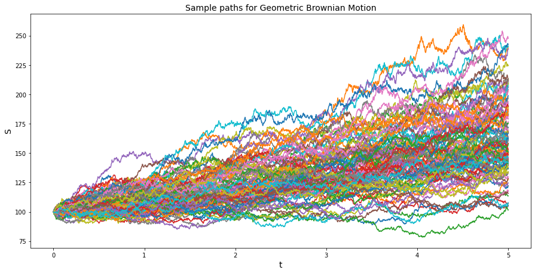

```python
# generate 100 paths by calling SDE_GBM() and adjust figure size
t, S = SDE_GBM(S0 = 100, tf = 5, mu = 0.1, sigma = 0.1, Npaths = 100)
plt.figure(figsize=(15,7.2))

# Plot paths
plt.plot(t,S)
plt.xlabel("t", fontsize=14)
plt.ylabel("S", fontsize=14)
plt.title("Sample paths for Geometric Brownian Motion", fontsize=14)
plt.show()
```

We now make a plot showing the mean +/- standard deviation for the 2000 paths as a function of time. As expected, the mean is increasing, but we also note the standard deviation is also increasing as time progresses (the width of the orange area increases).

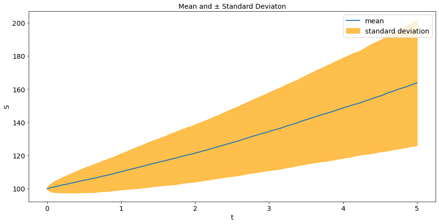

```python
# generate 2000 paths by calling SDE_GBM()
t, S = SDE_GBM(S0 = 100, tf = 5, mu = 0.1, sigma = 0.1, Npaths = 2000)

# adjust figure size
plt.figure(figsize=(15,7.2))

# compute the mean and standard deviation for these paths
S_mean = np.mean(S,1)
S_std = np.std(S,1)

# plot Mean and ± Std.
plt.fill_between(t,
                 S_mean - S_std,
                 S_mean + S_std,
                 alpha = 0.7, color = "orange", label = "standard deviation")
plt.plot(t, S_mean, linewidth = 2, label = "mean")
plt.xlabel("t", fontsize=14)
plt.ylabel("S", fontsize=14)
plt.title("Mean and ± Standard Deviaton", fontsize=14)
plt.legend(fontsize=14)
plt.xticks(fontsize = 14)
plt.yticks(fontsize = 14)
plt.show()
```

```
The mean of day 200 is 105.56751963854354
The standard deviation of day 200 is 7.701076385282225
The median of day 200 is 105.17260507330388
The mean of day 500 is 114.93129621239656
The standard deviation of day 500 is 13.075785667670502
The median of day 500 is 114.26271784569579
The mean of day 1825 is 165.62500225077133
The standard deviation of day 1825 is 36.97774799700866
The median of day 1825 is 161.3674585633064
```

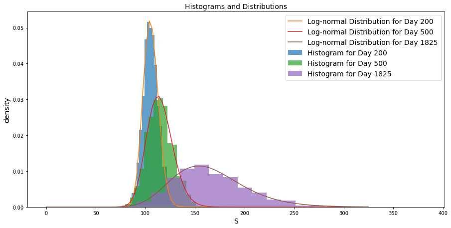

```python
# Plot histograms and log-normal distributions

# set x array
x = np.linspace(0, 325, 101)

# adjust figure size
plt.figure(figsize=(15,7.2))

# the 4 comments below apply to all 3 histograms and distributions
# we take alpha = 0.7 for some transparency and use 21 bins
# we use lognorm.fit to obtain log-normal distributions for our histograms
# floc = 0 is important; it will fix the location parameter as 0 while varying the other properties of the distribution
# we then generate the pdfs and plot them

plt.hist(S[200,:], bins = 21, density=True, alpha = 0.7, label = "Histogram for Day 200")
s, loc, scale = lognorm.fit(S[200,:], floc = 0)
pdf = lognorm.pdf(x, s, scale = scale)
plt.plot(x, pdf, label = "Log-normal Distribution for Day 200" )

# print mean, standard deviation, and median for time 1
print("The mean of day 200 is", np.mean(S[200,:]))
print("The standard deviation of day 200 is", np.std(S[200,:]))
print("The median of day 200 is", np.median(S[200,:]))

plt.hist(S[500,:], bins = 21, density=True, alpha = 0.7, label = "Histogram for Day 500")
s, loc, scale = lognorm.fit(S[500,:], floc = 0)
pdf = lognorm.pdf(x, s, scale = scale)
plt.plot(x, pdf, label = "Log-normal Distribution for Day 500" )

# print mean, standard deviation, and median for time 2
print("The mean of day 500 is", np.mean(S[500,:]))
print("The standard deviation of day 500 is", np.std(S[500,:]))
print("The median of day 500 is", np.median(S[500,:]))

# the last day is 365*5 = 1825
plt.hist(S[-1,:], bins = 21, density=True, alpha = 0.7, label = "Histogram for Day 1825")
s, loc, scale = lognorm.fit(S[-1,:], floc = 0)
pdf = lognorm.pdf(x, s, scale = scale)
plt.plot(x, pdf, label = "Log-normal Distribution for Day 1825" )

# print mean, standard deviation, and median for time 3
print("The mean of day 1825 is", np.mean(S[-1,:]))
print("The standard deviation of day 1825 is", np.std(S[-1,:]))
print("The median of day 1825 is", np.median(S[-1,:]))

# plot figure
plt.xlabel("S", fontsize=14)
plt.ylabel("density", fontsize=14)
plt.title("Histograms and Distributions", fontsize=14)
plt.legend(fontsize=14)
plt.show()
```

We observe that these distributions follow the [Log-normal Distribution](https://en.wikipedia.org/wiki/Log-normal_distribution). We note that the mean of the Log-normal distribution is given by $\exp \left(\mu+\frac{\sigma^{2}}{2}\right)$, whereas the median of the Log-normal distribution is given by $\exp (\mu)$. Thus, we would expect the median of the distributions to be less than the mean in all distributions. This agrees with our data, since in all three of our histograms, we note that the median of the distribution is less than the mean. As the day number increases, the mean and the standard deviation both increase. We finally note that our (asymmetric) distributions have slightly positive skew (and the positive skewness seems to increase as the day number increases), which is the main reason why the medians of the distributions are less than the means. The slightly positive skew of shows that an investor should expect small losses frequently, but they will also obtain some large gains from this investment. These types of distributions are generally preferred because of the relatively high probability of obtaining large profits which compensate for the small losses.

### Sources

https://quant.stackexchange.com/questions/64341/what-is-better-a-negatively-skewed-return-or-a-positively-skewed-returns-distri https://corporatefinanceinstitute.com/resources/knowledge/other/positively-skewed-distribution/ https://www.investopedia.com/terms/s/skewness.asp https://en.wikipedia.org/wiki/Log-normal_distribution